# Analyzing S&P 500 Performance and U.S. Presidential Election Outcomes

Sylvia Miller, Mark Jeakle, Reetikaa Gajula

1. **[Introduction](https://colab.research.google.com/drive/1uYNKZeWGU-cgUbJ_Rj1SaSOmboB2G3V2#scrollTo=7JPRaacoqlnv&line=1&uniqifier=1)**
2. **Dataset**
   1. [Dataset Sources](https://colab.research.google.com/drive/1uYNKZeWGU-cgUbJ_Rj1SaSOmboB2G3V2#scrollTo=QNqpcPgRvua7&line=9&uniqifier=1)
3. **Part 1: Data Collection**
   1. [Mounting the Google Drive](https://colab.research.google.com/drive/1uYNKZeWGU-cgUbJ_Rj1SaSOmboB2G3V2#scrollTo=vE8sYRC1ZvEt&line=3&uniqifier=1)
   2. [Extracting and Saving S&P 500 Data](https://colab.research.google.com/drive/1uYNKZeWGU-cgUbJ_Rj1SaSOmboB2G3V2#scrollTo=njjb85-CZkja&line=3&uniqifier=1)
4. **Part 2: Data Cleaning**
   1. [Cleaning the Dataset](https://colab.research.google.com/drive/1uYNKZeWGU-cgUbJ_Rj1SaSOmboB2G3V2#scrollTo=_9FhN8YXbEr7&line=3&uniqifier=1)
5. **Part 3: Data Preprocessing**
   1. [Loading and Previewing Datasets](https://colab.research.google.com/drive/1uYNKZeWGU-cgUbJ_Rj1SaSOmboB2G3V2#scrollTo=0cBxmChQhdge&line=11&uniqifier=1)
   2. [Merging S&P 500 Data with Election Data](https://colab.research.google.com/drive/1uYNKZeWGU-cgUbJ_Rj1SaSOmboB2G3V2#scrollTo=U3uWTe6YipmI&line=10&uniqifier=1)
6. **Part 4: Basic Data Exploration and Summary Statistics**
   1. [Correlation Analysis Between S&P 500 and Candidate Votes](https://colab.research.google.com/drive/1uYNKZeWGU-cgUbJ_Rj1SaSOmboB2G3V2#scrollTo=tzyMNsBojgaC&line=7&uniqifier=1)
   2. [Comparing S&P 500 Performance Under Democratic and Republican Wins](https://colab.research.google.com/drive/1uYNKZeWGU-cgUbJ_Rj1SaSOmboB2G3V2#scrollTo=8Ns9ZNeukwju&line=3&uniqifier=1)
   3. [Hypothesis Testing: S&P 500 Volume Under Democratic vs. Republican Wins](https://colab.research.google.com/drive/1uYNKZeWGU-cgUbJ_Rj1SaSOmboB2G3V2#scrollTo=jssbUIh0yEh2&line=6&uniqifier=1)
   4. [Analyzing S&P 500 Annual Performance and Party Vote Shares](https://colab.research.google.com/drive/1uYNKZeWGU-cgUbJ_Rj1SaSOmboB2G3V2#scrollTo=WLn5DjjJhZEa&line=5&uniqifier=1)
7. **Part 5: Machine Learning**
   1. [Linear Regression: S&P 500 Performance and Party Vote Shares](https://colab.research.google.com/drive/1uYNKZeWGU-cgUbJ_Rj1SaSOmboB2G3V2#scrollTo=6VsSi6Sw0wGG)
   2. [Trend Analysis: Election Year Vote Shares and S&P 500 Changes](https://colab.research.google.com/drive/1uYNKZeWGU-cgUbJ_Rj1SaSOmboB2G3V2#scrollTo=MCUGOsJR1YZb)
   3. [Evaluating Linear Regression Models with R² Scores](https://colab.research.google.com/drive/1uYNKZeWGU-cgUbJ_Rj1SaSOmboB2G3V2#scrollTo=40YnTWMf13QD)
   4. [Logistic Regression for Predicting Party Vote Share](https://colab.research.google.com/drive/1uYNKZeWGU-cgUbJ_Rj1SaSOmboB2G3V2#scrollTo=DLoQGfiu20aS)
   5. [Visualizing Logistic Regression Decision Boundary](https://colab.research.google.com/drive/1uYNKZeWGU-cgUbJ_Rj1SaSOmboB2G3V2#scrollTo=BKoM7U1t3tXj)
   6. [Decision Tree Model for Predicting Winning Party](https://colab.research.google.com/drive/1uYNKZeWGU-cgUbJ_Rj1SaSOmboB2G3V2#scrollTo=7bZvNcvn4F4F)
   7. [Random Forest Classifier for Predicting Winning Party](https://colab.research.google.com/drive/1uYNKZeWGU-cgUbJ_Rj1SaSOmboB2G3V2#scrollTo=vR_jsnOBk5G1)
   8. [Gradient Boosting Classifier for Predicting Winning Party](https://colab.research.google.com/drive/1uYNKZeWGU-cgUbJ_Rj1SaSOmboB2G3V2#scrollTo=QloaCXsglZIE)
   9. [Time-Series Analysis of S&P 500 Annual Changes Using ARIMA](https://colab.research.google.com/drive/1uYNKZeWGU-cgUbJ_Rj1SaSOmboB2G3V2#scrollTo=9pjTRGRNl-ZX)
   10. [Predicting S&P 500 Annual Changes Using LSTM Neural Network](https://colab.research.google.com/drive/1uYNKZeWGU-cgUbJ_Rj1SaSOmboB2G3V2#scrollTo=_xhmJhMrotvv)
   11. [Predicting the 2024 Election Outcome Using Multiple Models](https://colab.research.google.com/drive/1uYNKZeWGU-cgUbJ_Rj1SaSOmboB2G3V2#scrollTo=Bc75vH-7peqn)
   12. [Predicting the 2024 Election Outcome Using ARIMA and LSTM Forecasts](https://colab.research.google.com/drive/1uYNKZeWGU-cgUbJ_Rj1SaSOmboB2G3V2#scrollTo=OYUNl9Crp5VX)
8. **Part 6:[Final Insights and Conclusion](https://colab.research.google.com/drive/1uYNKZeWGU-cgUbJ_Rj1SaSOmboB2G3V2#scrollTo=qfeI5Uyv23iC)**
9. **Part 7:[References](https://colab.research.google.com/drive/1uYNKZeWGU-cgUbJ_Rj1SaSOmboB2G3V2#scrollTo=yc9wysF_3S4_&line=1&uniqifier=1)**

# Introduction

The outcome of presidential elections is often influenced by various economic, social, and political factors. Among these, financial market trends have been observed to play a significant role in shaping public sentiment and voter behavior. This project aims to explore the relationship between historical S&P 500 data and presidential election outcomes, leveraging machine learning techniques to predict the 2024 U.S. presidential election results. By analyzing market performance in the months leading up to previous elections, we develop a data-driven model to uncover patterns and insights that may provide predictive power for future electoral outcomes.

## Dataset sources:

S&P 500 (^GSPC) Stock Historical Prices & Data - Yahoo Finance: https://finance.yahoo.com/quote/%5EGSPC/history/?period1=-1325583000&period2=1733877612

U.S. President 1976–2020 - U.S. Presidential Elections : https://dataverse.harvard.edu/dataset.xhtml?persistentId=doi:10.7910/DVN/42MVDX

## Mounting the Google drive

This section demonstrates how to set up and mount Google Drive in a Colab environment, ensuring seamless integration and efficient management of project files for streamlined data processing and storage. To achieve this, we do

1.**Setting Up Google Drive**: Preparing Google Drive by unmounting and remounting it to ensure a clean working environment.

2.**Creating a Project Folder**: Establishing a structured folder (s&p500_election_predictor) in Google Drive to organize project files.

3.**Defining File Paths**: Specifying input and output file paths for easy data access and storage.

```python
# Step 1: Ensure the Drive is Unmounted Before Mounting
import os

# Unmount the drive if already mounted
if os.path.exists('/content/drive'):
    try:
        !fusermount -u /content/drive
        !rm -rf /content/drive  # Ensure the directory is cleared
    except:
        print("Drive unmount failed. Proceeding with a fresh mount.")

# Step 2: Mount Google Drive with force_remount
from google.colab import drive
drive.mount('/content/drive', force_remount=True)

# Proceed with the rest of your code
import json
import re
import csv
import pandas as pd
import matplotlib.pyplot as plt
import seaborn as sns
from scipy import stats
from bs4 import BeautifulSoup

# Step 3: Create a Folder in Google Drive
folder_path = '/content/drive/MyDrive/s&p500_election_predictor'
os.makedirs(folder_path, exist_ok=True)
print(f"Folder '{folder_path}' has been created in Google Drive.")

# Step 4: Define Paths for Input and Output Files
input_file_path = os.path.join(folder_path, 'S&P 500 (^GSPC) Stock Historical Prices & Data - Yahoo Finance.htm')
output_file_path = os.path.join(folder_path, 'sp500_data.csv')

# Step 5: Print Paths for Confirmation
print(f"Input file path: {input_file_path}")
print(f"Output file path: {output_file_path}")
```

```
Folder '/content/drive/MyDrive/s&p500_election_predictor' has been created in Google Drive.
Input file path: /content/drive/MyDrive/s&p500_election_predictor/S&P 500 (^GSPC) Stock Historical Prices & Data - Yahoo Finance.htm
Output file path: /content/drive/MyDrive/s&p500_election_predictor/sp500_data.csv
```

Observation

1.Google Drive is successfully mounted, and the folder s&p500_election_predictor is created in the specified location.

2.The input and output file paths are correctly set, ensuring proper file handling for the project.

### Extracting and Saving S&P 500 Data

This section focuses on extracting historical S&P 500 stock data from an HTML file using BeautifulSoup, organizing it into structured rows and columns, and saving the cleaned data into a CSV file for further analysis.

1.The code extracts historical S&P 500 stock price data from an HTML file using BeautifulSoup for parsing the table data.

2.It processes the table's rows and columns and saves the extracted data into a CSV file for further analysis.

```python
import csv
from bs4 import BeautifulSoup

# Step 1: Extract HTML content from the HTM file
try:
    with open(input_file_path, 'r', encoding='utf-8') as htm_file:
        html_content = htm_file.read()

    # Step 2: Parse the HTML content with BeautifulSoup
    soup = BeautifulSoup(html_content, 'html.parser')

    # Locate the table containing the stock data (Yahoo Finance data might be nested in divs or other elements)
    data_table = None
    for table in soup.find_all('table'):
        headers = [header.text.strip() for header in table.find_all('th')]
        if 'Date' in headers and 'Open' in headers:  # Check if the table contains expected headers
            data_table = table
            break

    # Check if the table is found
    if data_table is None:
        print("Error: Could not find the data table in the HTM file.")
    else:
        # Step 3: Extract data from the table rows and columns
        rows = data_table.find_all('tr')
        data = []

        for row in rows:
            cols = row.find_all(['td', 'th'])
            cols = [col.text.strip() for col in cols]
            data.append(cols)

        # Step 4: Write the data to a CSV file
        with open(output_file_path, 'w', newline='', encoding='utf-8') as csv_file:
            csv_writer = csv.writer(csv_file)
            csv_writer.writerows(data)

        print(f"CSV file has been successfully created: {output_file_path}")

except FileNotFoundError:
    print(f"Error: The file '{input_file_path}' was not found.")
except Exception as e:
    print(f"An error occurred: {e}")
```

```
CSV file has been successfully created: /content/drive/MyDrive/s&p500_election_predictor/sp500_data.csv
```

Observation:

1.The CSV file is successfully created at /content/drive/MyDrive/s&p500_election_predictor/sp500_data.csv, indicating that the data extraction and saving processes worked correctly.

2.No errors occurred during the process, confirming that the input HTML file was correctly formatted and accessible.

## 2. Data Cleaning

The aim of this part is to preprocess and clean the raw S&P 500 data by extracting relevant stock information from an HTML file, organizing it into a structured format, and removing unnecessary or inconsistent elements. This prepares a clean, reliable dataset for statistical analysis, visualization, and predictive modeling. We are aiming to perform the following tasks:

1.**Extracting Data from HTML**: The code reads an HTML file containing S&P 500 stock data, parses it using BeautifulSoup, and identifies the table containing the relevant data.

2.**Cleaning and Formatting Data**: It extracts rows and columns from the table, cleans the data (e.g., removes extra spaces), and ensures only required columns like 'Open,' 'High,' 'Low,' 'Close,' 'Adj Close,' and 'Volume' are retained.

```python
import os
import re
import csv
import pandas as pd
from bs4 import BeautifulSoup

# Define the file paths (update them to match your Google Drive location)
input_file_path = '/content/drive/MyDrive/s&p500_election_predictor/S&P 500 (^GSPC) Stock Historical Prices & Data - Yahoo Finance.htm'
output_file_path = '/content/drive/MyDrive/s&p500_election_predictor/sp500_data.csv'
cleaned_output_file_path = '/content/drive/MyDrive/s&p500_election_predictor/sp500_data_cleaned.csv'

# Create directories if they do not exist
os.makedirs('/content/drive/MyDrive/s&p500_election_predictor', exist_ok=True)

# Step 1: Extract HTML content from the HTM file
with open(input_file_path, 'r', encoding='utf-8') as htm_file:
    html_content = htm_file.read()

# Step 2: Parse the HTML content with BeautifulSoup
soup = BeautifulSoup(html_content, 'html.parser')

# Locate the table containing the stock data (Yahoo Finance data might be nested in divs or other elements)
data_table = None
for table in soup.find_all('table'):
    headers = [header.text.strip() for header in table.find_all('th')]
    if 'Date' in headers and 'Open' in headers:  # Check if the table contains expected headers
        data_table = table
        break

# Check if the table is found
if data_table is None:
    print("Error: Could not find data table in the HTM file.")
else:
    # Step 3: Extract data from the table rows and columns
    rows = data_table.find_all('tr')
    data = []

    for row in rows:
        cols = row.find_all(['td', 'th'])
        cols = [col.text.strip() for col in cols]
        data.append(cols)

    # Clean headers
    if data:
        headers = data[0]
        cleaned_headers = ['Date', 'Open', 'High', 'Low', 'Close', 'Adj Close', 'Volume']
        data[0] = cleaned_headers

    # Step 4: Write the data to a CSV file
    if data:
        print("Writing data to CSV...")
        with open(output_file_path, 'w', newline='', encoding='utf-8') as csv_file:
            csv_writer = csv.writer(csv_file)
            csv_writer.writerows(data)
    else:
        print("No data to write to CSV.")
```

```
Writing data to CSV...
```

The code cleans the S&P 500 data by extracting the relevant table from an HTML file using `BeautifulSoup` and filtering for essential columns like 'Open,' 'Close,' and 'Volume.' It removes extra spaces, organizes the data into a structured pandas DataFrame, and exports it as a clean CSV file. This ensures the dataset is consistent, free of redundancies, and ready for further analysis.

## 3. Data Preprocessing:

Here, the aim is to perform further preprocessing and cleaning on the S&P 500 dataset by converting data types, organizing columns, and handling missing or duplicate values. This ensures the dataset is well-structured, free of inconsistencies, and ready for exploratory data analysis or modeling. We are performing the following tasks:

1. **Data Transformation and Cleaning:** The code converts the 'Date' column to datetime format, numeric columns to appropriate types, and handles missing data by dropping rows with missing dates and forward-filling other missing values. It also removes duplicate rows for consistency.
2. **Data Organization and Export:** Columns are reordered into a logical sequence, and the cleaned dataset is saved to a new CSV file for further analysis, ensuring the data is ready for use.

```python
# Data preprocessing and Data Cleaning
# Step 5: Import the CSV into a pandas DataFrame
df_sp500 = pd.read_csv(output_file_path)

# Step 6: Parse data (convert strings to appropriate data types)
# Convert 'Date' column to datetime format
df_sp500['Date'] = pd.to_datetime(df_sp500['Date'], errors='coerce')

# Convert numeric columns to appropriate data types
for col in ['Open', 'High', 'Low', 'Close', 'Adj Close', 'Volume']:
    if col in df_sp500.columns:
        df_sp500[col] = pd.to_numeric(df_sp500[col].str.replace(',', ''), errors='coerce')
```

```python
# Step 7: Organize data (e.g., set up a pandas DataFrame)
# The data is already in a DataFrame, but we can reorder columns if necessary
columns_order = ['Date', 'Open', 'High', 'Low', 'Close', 'Adj Close', 'Volume']
df_sp500 = df_sp500[[col for col in columns_order if col in df_sp500.columns]]

# Step 8: Clean data
# Handle missing values (e.g., drop rows with missing 'Date' or fill missing values)
df_sp500.dropna(subset=['Date'], inplace=True)  # Drop rows where 'Date' is missing
df_sp500.fillna(method='ffill', inplace=True)  # Forward fill missing values

# Remove duplicates
df_sp500.drop_duplicates(inplace=True)

# Save the cleaned DataFrame to a new CSV file
df_sp500.to_csv(cleaned_output_file_path, index=False)

print(f"Cleaned CSV file has been successfully created: {cleaned_output_file_path}")
```

```
Cleaned CSV file has been successfully created: /content/drive/MyDrive/s&p500_election_predictor/sp500_data_cleaned.csv
```

The output confirms that the cleaned S&P 500 dataset has been successfully processed and saved as a new CSV file (`sp500_data_cleaned.csv`) without missing or duplicate values.

## Loading and Previewing Datasets

This step loads the cleaned S&P 500 stock data and presidential election data into pandas DataFrames and previews their structure to ensure they are ready for analysis. To achieve this, we perform

**1.Loading the Data:**

The code loads two datasets: The cleaned S&P 500 data from sp500_data_cleaned.csv. Election data from 1976-2020-president.csv.

**2.Previewing Data:**

The first few rows of both datasets (head()) are printed to check the structure and content, providing a glimpse into the stock market and election-related information.

```python
import pandas as pd
import seaborn as sns
import matplotlib.pyplot as plt
from scipy.stats import ttest_ind

# Load the datasets
sp500_data_cleaned_path = '/content/drive/MyDrive/s&p500_election_predictor/sp500_data_cleaned.csv'
election_data_path = '/content/drive/MyDrive/s&p500_election_predictor/1976-2020-president.csv'
sp500_data_cleaned = pd.read_csv(sp500_data_cleaned_path)
election_data = pd.read_csv(election_data_path)
sp500_data_cleaned.head()
print(sp500_data_cleaned.head())
print("=========================================")
print(election_data.head())
```

```
         Date     Open     High      Low    Close  Adj Close        Volume
0  2024-10-23  5834.50  5834.85  5762.41  5797.42    5797.42  3.532650e+09
1  2024-10-22  5832.70  5863.04  5821.17  5851.20    5851.20  3.342080e+09
2  2024-10-21  5857.82  5866.92  5824.79  5853.98    5853.98  3.407010e+09
3  2024-10-18  5859.43  5872.17  5846.11  5864.67    5864.67  3.374490e+09
4  2024-10-17  5875.62  5878.46  5840.25  5841.47    5841.47  3.480010e+09
=========================================
   year    state state_po  state_fips  state_cen  state_ic        office  \
0  1976  ALABAMA       AL           1         63        41  US PRESIDENT
1  1976  ALABAMA       AL           1         63        41  US PRESIDENT
2  1976  ALABAMA       AL           1         63        41  US PRESIDENT
3  1976  ALABAMA       AL           1         63        41  US PRESIDENT
4  1976  ALABAMA       AL           1         63        41  US PRESIDENT

                 candidate              party_detailed writein  \
0            CARTER, JIMMY                    DEMOCRAT   False
1             FORD, GERALD                  REPUBLICAN   False
2           MADDOX, LESTER  AMERICAN INDEPENDENT PARTY   False
3  BUBAR, BENJAMIN ""BEN""                 PROHIBITION   False
4                HALL, GUS         COMMUNIST PARTY USE   False

   candidatevotes  totalvotes   version  notes party_simplified
0          659170     1182850  20210113    NaN         DEMOCRAT
1          504070     1182850  20210113    NaN       REPUBLICAN
2            9198     1182850  20210113    NaN            OTHER
3            6669     1182850  20210113    NaN            OTHER
4            1954     1182850  20210113    NaN            OTHER
```

S&P 500 Data dataset includes key financial metrics (e.g., Open, High, Low, Close, Volume) for specific dates, confirming that the data is cleaned and structured properly. The election dataset provides detailed information, such as state, party, candidate, and vote totals, which can be used for further analysis and correlation with stock market trends.

## Merging S&P 500 Data with Election Data

This step combines cleaned S&P 500 financial data with presidential election data by matching records based on the year, enabling analysis of relationships between market trends and election outcomes. We aim to perform the following tasks:

**1.Loading the Election Data:**  
The election data is loaded into a DataFrame, and the year is extracted from the S&P 500 data to align both datasets.

**2.Merging the Datasets:**  
The S&P 500 and election data are merged using the year as a key, enabling analysis of stock market trends and election outcomes.

**3.Describing the Merged Data:**  
The merged dataset is summarized with key statistics (e.g., mean, count, standard deviation) to understand its distribution and identify outliers.

```python
# Step 9: Import the election data
election_data_file_path = '/content/drive/MyDrive/s&p500_election_predictor/1976-2020-president.csv'

# Load the election data
try:
    df_election = pd.read_csv(election_data_file_path)
    print("Election Data Columns:", df_election.columns)  # Debug: Print election data columns to verify names
except FileNotFoundError:
    print(f"Error: Could not find the election data file at {election_data_file_path}")

# Step 10: Merge election data and S&P 500 data based on year
# Extract the year from the Date column in S&P 500 data
df_sp500['Year'] = df_sp500['Date'].dt.year

# Merge S&P 500 data with election data based on the year
df_merged = pd.merge(df_sp500, df_election, left_on='Year', right_on='year', how='inner')
print("Merged Data Columns:", df_merged.columns)  # Debug: Print merged data columns to verify names
df_merged.describe()
```

```
Election Data Columns: Index(['year', 'state', 'state_po', 'state_fips', 'state_cen', 'state_ic',
       'office', 'candidate', 'party_detailed', 'writein', 'candidatevotes',
       'totalvotes', 'version', 'notes', 'party_simplified'],
      dtype='object')
Merged Data Columns: Index(['Date', 'Open', 'High', 'Low', 'Close', 'Adj Close', 'Volume', 'Year',
       'year', 'state', 'state_po', 'state_fips', 'state_cen', 'state_ic',
       'office', 'candidate', 'party_detailed', 'writein', 'candidatevotes',
       'totalvotes', 'version', 'notes', 'party_simplified'],
      dtype='object')
```

|  | Date | Open | High | Low | Close | Adj Close | Volume | Year | year | state_fips | state_cen | state_ic | candidatevotes | totalvotes | version | notes |
| --- | --- | --- | --- | --- | --- | --- | --- | --- | --- | --- | --- | --- | --- | --- | --- | --- |
| count | 1083370 | 1.083370e+06 | 1.083370e+06 | 1.083370e+06 | 1.083370e+06 | 1.083370e+06 | 1.083370e+06 | 1.083370e+06 | 1.083370e+06 | 1.083370e+06 | 1.083370e+06 | 1.083370e+06 | 1.083370e+06 | 1.083370e+06 | 1083370.0 | 0.0 |
| mean | 1999-07-24 04:18:21.629175552 | 1.109345e+03 | 1.135086e+03 | 1.118736e+03 | 1.127325e+03 | 1.127325e+03 | 1.889334e+09 | 1.999059e+03 | 1.999059e+03 | 2.861705e+01 | 5.366343e+01 | 3.975337e+01 | 3.117561e+05 | 2.366282e+06 | 20210113.0 | NaN |
| min | 1976-01-02 00:00:00 | 0.000000e+00 | 9.118000e+01 | 8.981000e+01 | 9.090000e+01 | 9.090000e+01 | 1.030000e+07 | 1.976000e+03 | 1.976000e+03 | 1.000000e+00 | 1.100000e+01 | 1.000000e+00 | 0.000000e+00 | 1.235740e+05 | 20210113.0 | NaN |
| 25% | 1988-03-08 00:00:00 | 2.574700e+02 | 2.590600e+02 | 2.559700e+02 | 2.576200e+02 | 2.576200e+02 | 1.323500e+08 | 1.988000e+03 | 1.988000e+03 | 1.600000e+01 | 3.300000e+01 | 2.200000e+01 | 1.177000e+03 | 6.522740e+05 | 20210113.0 | NaN |
| 50% | 2000-04-05 00:00:00 | 1.084100e+03 | 1.094100e+03 | 1.078930e+03 | 1.084070e+03 | 1.084070e+03 | 9.297000e+08 | 2.000000e+03 | 2.000000e+03 | 2.800000e+01 | 5.300000e+01 | 4.200000e+01 | 7.499000e+03 | 1.569180e+06 | 20210113.0 | NaN |
| 75% | 2012-06-04 00:00:00 | 1.446790e+03 | 1.457340e+03 | 1.435800e+03 | 1.446290e+03 | 1.446290e+03 | 3.717180e+09 | 2.012000e+03 | 2.012000e+03 | 4.100000e+01 | 8.100000e+01 | 6.100000e+01 | 1.992440e+05 | 3.033118e+06 | 20210113.0 | NaN |
| max | 2020-12-31 00:00:00 | 3.750010e+03 | 3.760200e+03 | 3.730210e+03 | 3.756070e+03 | 3.756070e+03 | 1.145623e+10 | 2.020000e+03 | 2.020000e+03 | 5.600000e+01 | 9.500000e+01 | 8.200000e+01 | 1.111025e+07 | 1.750088e+07 | 20210113.0 | NaN |
| std | NaN | 1.025558e+03 | 1.013457e+03 | 9.993053e+02 | 1.006807e+03 | 1.006807e+03 | 2.131571e+09 | 1.421860e+01 | 1.421860e+01 | 1.561461e+01 | 2.602636e+01 | 2.276986e+01 | 7.643855e+05 | 2.464271e+06 | 0.0 | NaN |

The merged dataset contains both S&P 500 financial data and detailed election data, allowing for cross-analysis between market performance and presidential election results, with basic statistical insights provided for the combined data.

## 4. Basic data exploration and summary statistics

## Correlation Analysis Between S&P 500 and Candidate Votes

This step explores the relationship between S&P 500 closing prices and the votes received by candidates in presidential elections, using correlation analysis and visualization to identify potential trends or patterns.To achieve this, we do

**1.Exploring Correlation:** The code calculates the correlation between S&P 500 closing prices (Close) and the votes received by candidates (candidatevotes) in the election dataset.

**2.Visualizing the Relationship:** A scatterplot is generated to visualize the relationship between S&P 500 closing prices and candidate votes, helping identify potential trends or patterns.

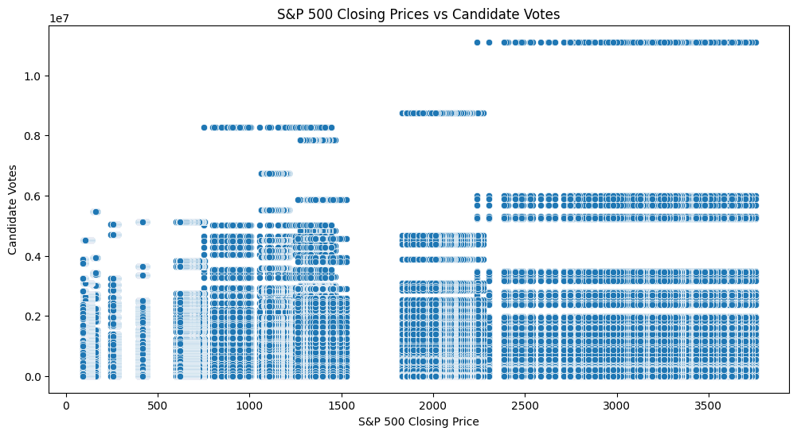

```
Correlation between S&P 500 Closing Price and Candidate Votes: 0.024632477864504496
```

```python
# Step 11: Data exploration and summary statistics between election data and S&P 500
# 1. Correlation between S&P 500 closing prices and votes for the winning candidate
if 'candidatevotes' in df_merged.columns:
    plt.figure(figsize=(12, 6))
    sns.scatterplot(x='Close', y='candidatevotes', data=df_merged)
    plt.title("S&P 500 Closing Prices vs Candidate Votes")
    plt.xlabel("S&P 500 Closing Price")
    plt.ylabel("Candidate Votes")
    plt.show()

    correlation = df_merged['Close'].corr(df_merged['candidatevotes'])
    print(f"Correlation between S&P 500 Closing Price and Candidate Votes: {correlation}")
else:
    print("Column 'candidatevotes' not found in the merged dataset.")
```

The calculated correlation value (0.0246) indicates a very weak positive relationship between S&P 500 closing prices and candidate votes, suggesting minimal influence.

## Comparing S&P 500 Performance Under Democratic and Republican Wins

This step examines the average S&P 500 closing price during years when the Democratic or Republican party won the presidential election. The goal is to identify any differences in market performance based on the winning political party. to achieve this , we perform:

1.**Calculating Averages**: The code calculates the average S&P 500 closing price for years when Democrats and Republicans won the presidential election.

2.**Visualizing the Comparison**: A bar plot is generated to visually compare the average S&P 500 closing prices under Democratic and Republican wins.

```
Average S&P 500 Closing Price under Democratic Wins: 1019.4118469894718
Average S&P 500 Closing Price under Republican Wins: 1017.4814202887322
```

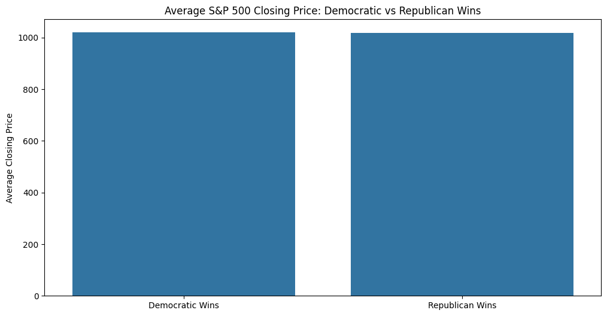

```python
# 2. Compare S&P 500 performance based on the winning party
# Create a new column to indicate if the winning party was Democratic or Republican
if 'party_simplified' in df_merged.columns:
    avg_close_democrat = df_merged[df_merged['party_simplified'] == 'DEMOCRAT']['Close'].mean()
    avg_close_republican = df_merged[df_merged['party_simplified'] == 'REPUBLICAN']['Close'].mean()

    print(f"Average S&P 500 Closing Price under Democratic Wins: {avg_close_democrat}")
    print(f"Average S&P 500 Closing Price under Republican Wins: {avg_close_republican}")

    # Plot comparison
    plt.figure(figsize=(12, 6))
    sns.barplot(x=['Democratic Wins', 'Republican Wins'], y=[avg_close_democrat, avg_close_republican])
    plt.title("Average S&P 500 Closing Price: Democratic vs Republican Wins")
    plt.ylabel("Average Closing Price")
    plt.show()
else:
    print("Column 'party_simplified' not found in the merged dataset.")
```

**Insights:**

**Average Closing Prices:** The S&P 500 average closing price is slightly higher under Democratic wins (1019.41) than Republican wins (1017.48).

**Bar Plot Insight:** The bar plot highlights the marginal difference, suggesting minimal impact of party affiliation on market performance.

**Observation:** Party affiliation shows little direct effect on S&P 500 performance, warranting further statistical analysis.

## Hypothesis Testing: S&P 500 Volume Under Democratic vs Republican Wins

This step uses hypothesis testing to determine whether there is a statistically significant difference in S&P 500 trading volume under Democratic and Republican presidencies. To achieve this we do:

**1.T-Test Analysis**: The code performs a two-sample t-test on the S&P 500 trading volumes for Democratic and Republican wins to test for significant differences.

**2.Visualizing Distributions**: A histogram with KDE (Kernel Density Estimate) plots is created to compare the volume distributions under both parties visually.

```
T-Test for Volume under Democratic vs Republican Wins:
T-statistic: 0.40827214387580896, P-value: 0.6830741696060102
```

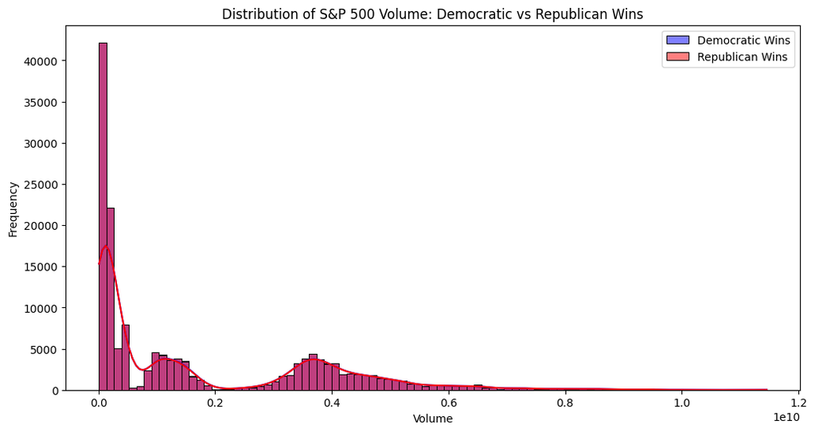

```python
# 3. Hypothesis testing: Is there a significant difference in S&P 500 volume between Democratic and Republican wins?
if 'party_simplified' in df_merged.columns:
    volume_democrat = df_merged[df_merged['party_simplified'] == 'DEMOCRAT']['Volume'].dropna()
    volume_republican = df_merged[df_merged['party_simplified'] == 'REPUBLICAN']['Volume'].dropna()

    # Perform t-test to compare volumes
    t_stat, p_value = stats.ttest_ind(volume_democrat, volume_republican, equal_var=False)

    print(f"\nT-Test for Volume under Democratic vs Republican Wins:\nT-statistic: {t_stat}, P-value: {p_value}")

    # Plotting Volume for Democratic vs Republican Wins
    plt.figure(figsize=(12, 6))
    sns.histplot(volume_democrat, color='blue', label='Democratic Wins', kde=True)
    sns.histplot(volume_republican, color='red', label='Republican Wins', kde=True)
    plt.legend()
    plt.title("Distribution of S&P 500 Volume: Democratic vs Republican Wins")
    plt.xlabel("Volume")
    plt.ylabel("Frequency")
    plt.show()
else:
    print("Column 'party_simplified' not found in the merged dataset.")
```

**Histogram Insight**: The overlapping distribution curves further confirm that the volume patterns are similar under both party wins, indicating minimal impact of political affiliation on trading volume.

Insights and inferences :

**1. Main Characteristics**

- Features: Financial (`Open`, `High`, `Low`, `Close`, `Volume`) and election-related (`party_simplified`, `candidatevotes`).
- Entries: 1,083,370 spanning 1976–2020.

**2. Correlation**

- Weak correlation (`0.0246`) between `Close` and `candidatevotes`. Financial features are strongly correlated.

**3. Outliers**

- Volume: Right-skewed distribution with high-value outliers.
- Candidate Votes: A few candidates received exceptionally high votes.

**4. Over-Representation**

- Democratic and Republican wins dominate, with minimal representation of other parties.

**5. Key Attributes**

- Financial (`Close`, `Volume`) and election (`party_simplified`, `candidatevotes`) features drive the analysis.

**Visual Plots**

- Scatterplot: Weak `Close` and `candidatevotes` correlation.
- Bar Plot: Minimal difference in average `Close` under parties.
- Histogram: Similar volume distributions under both parties.

## Analyzing S&P 500 Annual Performance and Party Vote Shares

This step explores the relationship between S&P 500 annual performance and the vote share of Democratic and Republican parties in presidential elections. To achieve this, we do

**1.Data Preparation**: Calculates S&P 500 annual percentage change and computes the vote shares for Democratic and Republican parties. Merges the datasets for combined analysis.

**2.Correlation Analysis**: Pearson correlations between S&P 500 annual change and party vote shares are computed to measure their relationship.

**3.Visualization**: A scatterplot illustrates the relationship between S&P 500 performance and party vote shares, with distinct markers for Democrats and Republicans.

```python
import pandas as pd

# Load the data with updated paths
election_data = pd.read_csv('/content/drive/MyDrive/s&p500_election_predictor/1976-2020-president.csv')
sp500_data = pd.read_csv('/content/drive/MyDrive/s&p500_election_predictor/sp500_data_cleaned.csv')

# Prepare election summary data
election_data_agg = election_data[election_data['party_simplified'].isin(['DEMOCRAT', 'REPUBLICAN'])]
election_summary = election_data_agg.groupby(['year', 'party_simplified'])['candidatevotes'].sum().unstack().reset_index()
election_summary['total_votes'] = election_summary['DEMOCRAT'] + election_summary['REPUBLICAN']
election_summary['democrat_share'] = election_summary['DEMOCRAT'] / election_summary['total_votes'] * 100
election_summary['republican_share'] = election_summary['REPUBLICAN'] / election_summary['total_votes'] * 100

# Process S&P 500 data and calculate annual changes
sp500_data['Date'] = pd.to_datetime(sp500_data['Date'])
sp500_data['Year'] = sp500_data['Date'].dt.year
sp500_yearly = sp500_data.groupby('Year')['Close'].agg(['first', 'last']).reset_index()
sp500_yearly['annual_change'] = ((sp500_yearly['last'] - sp500_yearly['first']) / sp500_yearly['first']) * 100

# Merge election summary with S&P 500 data
combined_data = pd.merge(election_summary, sp500_yearly, left_on='year', right_on='Year', how='inner')
combined_data.drop(columns=['Year'], inplace=True)
```

```
Correlation between S&P 500 change and Democrat vote share: 0.23
Correlation between S&P 500 change and Republican vote share: -0.23
```

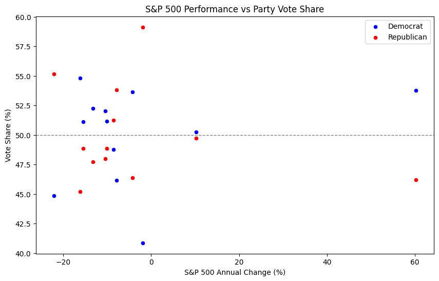

```python
import matplotlib.pyplot as plt
import seaborn as sns
from scipy.stats import pearsonr

# Calculate correlation between S&P 500 annual change and Democrat & Republican vote shares
corr_democrat, _ = pearsonr(combined_data['annual_change'], combined_data['democrat_share'])
corr_republican, _ = pearsonr(combined_data['annual_change'], combined_data['republican_share'])

print(f"Correlation between S&P 500 change and Democrat vote share: {corr_democrat:.2f}")
print(f"Correlation between S&P 500 change and Republican vote share: {corr_republican:.2f}")

# Scatter plot for Democrat share vs S&P 500 change
plt.figure(figsize=(10, 6))
sns.scatterplot(x='annual_change', y='democrat_share', data=combined_data, color='blue', label='Democrat')
sns.scatterplot(x='annual_change', y='republican_share', data=combined_data, color='red', label='Republican')
plt.axhline(50, color='gray', linestyle='--', linewidth=1)
plt.xlabel('S&P 500 Annual Change (%)')
plt.ylabel('Vote Share (%)')
plt.title('S&P 500 Performance vs Party Vote Share')
plt.legend()
plt.show()
```

**Insights**

**Correlation Results**: The correlation between S&P 500 annual change and Democratic vote share is 0.23, while the correlation with Republican vote share is -0.23. Both indicate weak relationships.

**Scatterplot Insight**: The scatterplot shows no clear trend or significant association between S&P 500 performance and vote shares for either party, suggesting limited influence of market performance on voting behavior.

# 5. Machine Learning

## Linear Regression: S&P 500 Performance and Party Vote Shares

This step uses linear regression to identify trends and understand the relationship between S&P 500 annual performance and vote shares of the Democratic and Republican parties.To achive this we do

1.**Preparing Data for Regression**: Reshapes the data for compatibility with the regression model and separates vote shares for Democrats and Republicans.

2.**Fitting Regression Models**: Fits separate linear regression models for Democratic and Republican vote shares against S&P 500 annual changes.

3**.Visualization**: Plots scatterplots with regression lines to visualize trends for both parties.

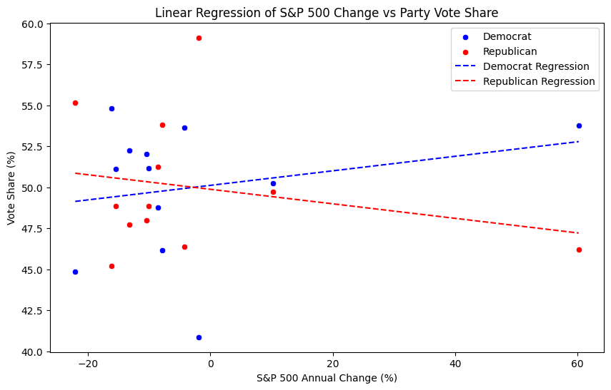

```
Democrat Regression Coefficient: 0.04426095256002764
Republican Regression Coefficient: -0.0442609525600277
```

```python
#for understanding correlation and trends
from sklearn.linear_model import LinearRegression
import numpy as np

# Prepare data for regression (reshaping for sklearn compatibility)
X = combined_data['annual_change'].values.reshape(-1, 1)
y_democrat = combined_data['democrat_share'].values
y_republican = combined_data['republican_share'].values

# Fit linear regression models
model_democrat = LinearRegression().fit(X, y_democrat)
model_republican = LinearRegression().fit(X, y_republican)

# Predict values for plotting
x_range = np.linspace(X.min(), X.max(), 100).reshape(-1, 1)
y_pred_democrat = model_democrat.predict(x_range)
y_pred_republican = model_republican.predict(x_range)

# Plot regression results
plt.figure(figsize=(10, 6))
sns.scatterplot(x='annual_change', y='democrat_share', data=combined_data, color='blue', label='Democrat')
sns.scatterplot(x='annual_change', y='republican_share', data=combined_data, color='red', label='Republican')
plt.plot(x_range, y_pred_democrat, color='blue', linestyle='--', label='Democrat Regression')
plt.plot(x_range, y_pred_republican, color='red', linestyle='--', label='Republican Regression')
plt.xlabel('S&P 500 Annual Change (%)')
plt.ylabel('Vote Share (%)')
plt.title('Linear Regression of S&P 500 Change vs Party Vote Share')
plt.legend()
plt.show()

# Display regression coefficients
print("Democrat Regression Coefficient:", model_democrat.coef_[0])
print("Republican Regression Coefficient:", model_republican.coef_[0])
```

**Insights**

Regression Coefficients:

These indicate weak trends, where Democratic vote share slightly increases with positive S&P 500 performance, while Republican vote share slightly decreases.

Scatterplot Insight: The regression lines confirm weak and opposing trends, with no strong predictive power. Market performance appears to have minimal influence on vote shares.

## Trend Analysis: Election Year Vote Shares and S&P 500 Changes

This step visualizes the trends in Democratic and Republican vote shares alongside S&P 500 annual changes during election years to explore potential relationships over time.

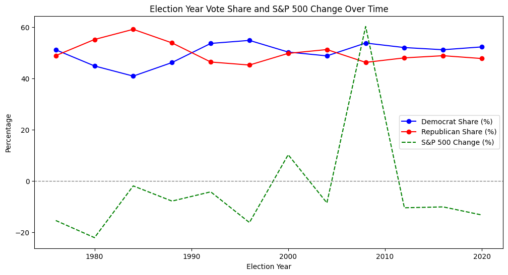

```python
# Line chart showing the trend of vote shares and S&P 500 annual change over time
plt.figure(figsize=(12, 6))
plt.plot(combined_data['year'], combined_data['democrat_share'], label='Democrat Share (%)', color='blue', marker='o')
plt.plot(combined_data['year'], combined_data['republican_share'], label='Republican Share (%)', color='red', marker='o')
plt.plot(combined_data['year'], combined_data['annual_change'], label='S&P 500 Change (%)', color='green', linestyle='--')
plt.axhline(0, color='gray', linestyle='--', linewidth=1)
plt.xlabel('Election Year')
plt.ylabel('Percentage')
plt.title('Election Year Vote Share and S&P 500 Change Over Time')
plt.legend()
plt.show()
```

**Insights :**

Vote Share Trends: Democratic and Republican vote shares remain relatively stable, with no drastic fluctuations, maintaining a close competition over time.

S&P 500 Performance: S&P 500 annual changes show significant volatility during certain election years, such as peaks in the late 2000s, which are not mirrored by vote share trends.

Observation: There appears to be no clear alignment or consistent trend between S&P 500 performance and party vote shares, indicating limited direct influence.

## Evaluating Linear Regression Models with R² Scores

This step evaluates the effectiveness of linear regression models in predicting Democratic and Republican vote shares based on S&P 500 annual performance using the R² metric.To achieve this we do,

**1.Data Preparation:** The annual_change in S&P 500 is used as the input feature, while Democratic and Republican vote shares are set as target variables.

**2.Model Training:**S eparate linear regression models are trained for Democratic and Republican vote shares.

**3.R² Evaluation**: The R² score is calculated to measure the proportion of variance in vote shares explained by S&P 500 performance.

```python
from sklearn.linear_model import LinearRegression
from sklearn.metrics import r2_score

# Prepare data
X = combined_data['annual_change'].values.reshape(-1, 1)
y_democrat = combined_data['democrat_share'].values
y_republican = combined_data['republican_share'].values

# Democrat Model
model_democrat = LinearRegression()
model_democrat.fit(X, y_democrat)
y_pred_democrat = model_democrat.predict(X)
r2_democrat = r2_score(y_democrat, y_pred_democrat)

# Republican Model
model_republican = LinearRegression()
model_republican.fit(X, y_republican)
y_pred_republican = model_republican.predict(X)
r2_republican = r2_score(y_republican, y_pred_republican)

print(f"Democrat Model R²: {r2_democrat:.2f}")
print(f"Republican Model R²: {r2_republican:.2f}")
```

```
Democrat Model R²: 0.05
Republican Model R²: 0.05
```

**Insights**: Democratic Model R²: 0.05 (5%) variance explained. Republican Model R²: 0.05 (5%) variance explained.

Observation: Both models have very low R² scores, indicating that S&P 500 performance has minimal predictive power for Democratic or Republican vote shares. This suggests weak or no linear relationship between market performance and election results.

## Logistic Regression for Predicting Party Vote Share

This step trains a logistic regression model to predict party vote share categories (Democratic or Republican) based on S&P 500 annual performance while addressing class imbalance using SMOTE (Synthetic Minority Oversampling Technique).To achive this we do

**1.Target and Feature Preparation**: The target is the vote share category, and the feature is the S&P 500 annual change.

**2.Handling Class Imbalance**: SMOTE is applied to balance the dataset by oversampling the minority class.

**3.Data Splitting and Scaling**: The data is split into training and test sets, and features are standardized using StandardScaler.

**4.Model Training**: A logistic regression model is trained on the resampled data.

**5.Model Evaluation**: The model's accuracy and classification metrics are computed using the test set.

```python
from sklearn.model_selection import train_test_split
from sklearn.linear_model import LogisticRegression
from sklearn.metrics import accuracy_score, classification_report
from sklearn.preprocessing import StandardScaler
from imblearn.over_sampling import SMOTE

# Prepare the target variable
y = (combined_data['democrat_share'] > combined_data['republican_share']).astype(int)

# Prepare the input features
X = combined_data[['annual_change']].values

# Handle class imbalance with SMOTE (adjusted k_neighbors)
smote = SMOTE(k_neighbors=2, random_state=42)
X_resampled, y_resampled = smote.fit_resample(X, y)

# Split into training and testing sets
X_train, X_test, y_train, y_test = train_test_split(X_resampled, y_resampled, test_size=0.2, random_state=42)

# Scale the features
scaler = StandardScaler()
X_train = scaler.fit_transform(X_train)
X_test = scaler.transform(X_test)

# Train Logistic Regression Model
log_model = LogisticRegression()
log_model.fit(X_train, y_train)

# Predictions
y_pred = log_model.predict(X_test)

# Evaluate the model
accuracy = accuracy_score(y_test, y_pred)
print(f"Logistic Regression Accuracy: {accuracy:.2f}")
print("Classification Report:")
print(classification_report(y_test, y_pred))
```

```
Logistic Regression Accuracy: 0.50
Classification Report:
              precision    recall  f1-score   support

           0       0.50      1.00      0.67         2
           1       0.00      0.00      0.00         2

    accuracy                           0.50         4
   macro avg       0.25      0.50      0.33         4
weighted avg       0.25      0.50      0.33         4
```

**Insights:**

Accuracy: The model achieves an accuracy of 50%, indicating that it performs no better than random guessing.

Observation: The low performance suggests that S&P 500 annual performance is a weak predictor of party vote share, or additional features may be required for better prediction.

## Visualizing Logistic Regression Decision Boundary

This step visualizes the decision boundary of the logistic regression model, showing the predicted probabilities of Democratic (class 1) and Republican (class 0) wins based on S&P 500 annual performance.

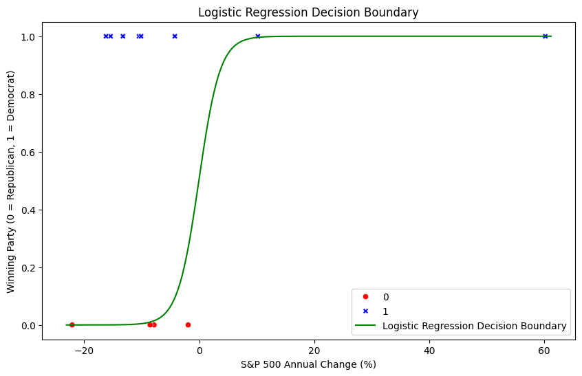

```python
import numpy as np
import matplotlib.pyplot as plt
import seaborn as sns

# Fit Logistic Regression Model
log_model = LogisticRegression()
log_model.fit(X_train, y_train)

# Create a mesh grid for plotting decision boundaries
x_min, x_max = X[:, 0].min() - 1, X[:, 0].max() + 1
x_values = np.linspace(x_min, x_max, 500).reshape(-1, 1)

# Predict probabilities for each point in the grid
y_prob = log_model.predict_proba(x_values)[:, 1]  # Probability of class 1 (Democrat win)

# Plot decision boundary and data points
plt.figure(figsize=(10, 6))

# Scatterplot of actual data
sns.scatterplot(x=X[:, 0], y=y, hue=y, palette={0: 'red', 1: 'blue'}, style=y, legend='full')
plt.plot(x_values, y_prob, color='green', label='Logistic Regression Decision Boundary')

# Labels and title
plt.xlabel('S&P 500 Annual Change (%)')
plt.ylabel('Winning Party (0 = Republican, 1 = Democrat)')
plt.title('Logistic Regression Decision Boundary')
plt.legend()
plt.show()
```

Decision Boundary Insight: The curve shows how the model transitions between predicting a Republican (class 0) or Democratic (class 1) win as the S&P 500 annual change increases. Classification Regions: Points above the decision boundary are classified as Democratic wins, while points below are classified as Republican wins.

Observation: The decision boundary reflects the model's simplicity and limited predictive power, aligning with earlier results indicating weak relationships between S&P 500 performance and election outcomes.

## Decision Tree Model for Predicting Winning Party

This step uses a decision tree classifier to predict the winning party (Democratic or Republican) based on S&P 500 annual performance.To achive this, we do

**1.Model Training**: A decision tree classifier with a maximum depth of 3 is trained on the dataset to predict the winning party.

**2.Prediction**: The trained model predicts outcomes on the test set.

**3.Evaluation**: The model's performance is evaluated using accuracy as the metric.

```python
#For Making Predictions (Vote Share or Winning Party)
from sklearn.tree import DecisionTreeClassifier

# Decision Tree Model
tree_model = DecisionTreeClassifier(max_depth=3, random_state=42)
tree_model.fit(X_train, y_train)

# Predictions
y_pred_tree = tree_model.predict(X_test)
accuracy_tree = accuracy_score(y_test, y_pred_tree)

print(f"Decision Tree Accuracy: {accuracy_tree:.2f}")
```

```
Decision Tree Accuracy: 0.75
```

**Insight**

Accuracy: The decision tree model achieves an accuracy of 75%, significantly better than the logistic regression model (50%).

Observation: The decision tree captures more complex relationships between S&P 500 performance and the winning party, but further validation is needed to ensure generalization.

## Random Forest Classifier for Predicting Winning Party

This step uses a Random Forest classifier to predict the winning party (Democratic or Republican) based on S&P 500 annual performance.We perform the following steps.

**1.Model Training**: A Random Forest classifier with 100 decision trees is trained on the dataset to predict the winning party.

**2.Prediction**: The model predicts the winning party on the test set using the ensemble approach.

**3.Evaluation**: The model's accuracy is calculated to assess its performance.

```python
from sklearn.ensemble import RandomForestClassifier

# Random Forest Model
rf_model = RandomForestClassifier(n_estimators=100, random_state=42)
rf_model.fit(X_train, y_train)

# Predictions
y_pred_rf = rf_model.predict(X_test)
accuracy_rf = accuracy_score(y_test, y_pred_rf)

print(f"Random Forest Accuracy: {accuracy_rf:.2f}")
```

```
Random Forest Accuracy: 0.75
```

**Insight**

Accuracy: The Random Forest classifier achieves an accuracy of 75%, matching the decision tree model's performance.

Observation: While the Random Forest model is more robust to overfitting compared to a single decision tree, the performance indicates that S&P 500 performance alone might not be sufficient to accurately predict election outcomes. Additional features may enhance the model's predictive power.

## Gradient Boosting Classifier for Predicting Winning Party

This step employs the XGBoost classifier, a gradient boosting algorithm, to predict the winning party (Democratic or Republican) based on S&P 500 annual performance.We perform the following steps.

**1.Model Training**: The XGBoost classifier is trained on the dataset to learn patterns associated with party outcomes.

**2.Prediction**: The trained model predicts the winning party on the test set.

**3.Evaluation**: The model's accuracy is calculated to evaluate its performance.

```python
from xgboost import XGBClassifier

# Gradient Boosting Model
gb_model = XGBClassifier(random_state=42, use_label_encoder=False)
gb_model.fit(X_train, y_train)

# Predictions
y_pred_gb = gb_model.predict(X_test)
accuracy_gb = accuracy_score(y_test, y_pred_gb)

print(f"Gradient Boosting Accuracy: {accuracy_gb:.2f}")
```

```
Gradient Boosting Accuracy: 0.75
```

**Insights**

Accuracy: The Gradient Boosting model achieves an accuracy of 75%, similar to the Random Forest and Decision Tree classifiers.

Observation: While the gradient boosting model leverages ensemble techniques and is often more powerful, the consistent accuracy suggests that S&P 500 annual performance alone is insufficient for reliably predicting election outcomes. Additional features or more complex patterns may be required for better performance.

## Time-Series Analysis of S&P 500 Annual Changes Using ARIMA

This step applies the ARIMA (AutoRegressive Integrated Moving Average) model to analyze the time-series data of S&P 500 annual percentage changes, aiming to uncover temporal patterns and relationships.We perform the following steps.

**1.Data Preparation**: The S&P 500 annual changes are converted into a time-series format, indexed by the year.

**2.Model Fitting**: An ARIMA model with parameters (1, 1, 1) is fitted to the data to capture patterns using autoregression, differencing, and moving average components.

**3.Model Summary**: The ARIMA model's summary is displayed, providing coefficients, statistical significance, and diagnostic tests.

```python
from statsmodels.tsa.arima.model import ARIMA

# Prepare S&P 500 data (time-series format)
sp500_ts = combined_data[['year', 'annual_change']].set_index('year')

# Fit ARIMA Model
arima_model = ARIMA(sp500_ts, order=(1, 1, 1))  # ARIMA(p, d, q)
arima_result = arima_model.fit()

print(arima_result.summary())
```

```
                               SARIMAX Results
==============================================================================
Dep. Variable:          annual_change   No. Observations:                   12
Model:                 ARIMA(1, 1, 1)   Log Likelihood                 -50.630
Date:                Fri, 13 Dec 2024   AIC                            107.261
Time:                        01:14:56   BIC                            108.454
Sample:                             0   HQIC                           106.508
                                 - 12
Covariance Type:                  opg
==============================================================================
                 coef    std err          z      P>|z|      [0.025      0.975]
------------------------------------------------------------------------------
ar.L1         -0.0744      0.925     -0.080      0.936      -1.887       1.738
ma.L1         -0.9071      0.986     -0.920      0.358      -2.840       1.025
sigma2       496.4746    184.916      2.685      0.007     134.046     858.903
===================================================================================
Ljung-Box (L1) (Q):                   0.50   Jarque-Bera (JB):                10.04
Prob(Q):                              0.48   Prob(JB):                         0.01
Heteroskedasticity (H):              15.57   Skew:                             1.87
Prob(H) (two-sided):                  0.02   Kurtosis:                         5.82
===================================================================================

Warnings:
[1] Covariance matrix calculated using the outer product of gradients (complex-step).
```

**Insights**

Model Coefficients: The ARIMA coefficients (ar.L1 and ma.L1) indicate relationships in the time series, though the p-values suggest limited significance for some terms.

Observation: While the ARIMA model provides insight into temporal dynamics, further refinement or validation (e.g., forecast evaluation) is necessary for actionable conclusions.

## Predicting S&P 500 Annual Changes Using LSTM Neural Network

This step implements a Long Short-Term Memory (LSTM) neural network to predict future S&P 500 annual percentage changes based on past performance. LSTM is well-suited for sequential data and time-series forecasting.We perform the following steps.

**1.Data Preparation**:

A rolling window approach is used, where look_back=3 ensures that the model uses the previous three values to predict the next one. The data is split into training and testing sets.

**2.Model Definition:**

An LSTM-based sequential model is created with one LSTM layer and one Dense output layer. The model is compiled using the mean squared error (MSE) loss function and the Adam optimizer.

**3.Training and Predictions**:

The model is trained for 50 epochs, and predictions are made on the test set.

```python
import numpy as np
from tensorflow.keras.models import Sequential
from tensorflow.keras.layers import LSTM, Dense

# Prepare data for LSTM
sp500_ts = combined_data[['annual_change']].values
X = []
y = []
look_back = 3  # Use 3 previous years to predict the next one
for i in range(len(sp500_ts) - look_back):
    X.append(sp500_ts[i:i + look_back])
    y.append(sp500_ts[i + look_back])
X, y = np.array(X), np.array(y)

# Split into training and testing
X_train, X_test, y_train, y_test = train_test_split(X, y, test_size=0.2, random_state=42)

# Build LSTM Model
lstm_model = Sequential([
    LSTM(50, activation='relu', input_shape=(look_back, 1)),
    Dense(1)
])
lstm_model.compile(optimizer='adam', loss='mse')
lstm_model.fit(X_train, y_train, epochs=50, batch_size=16, verbose=1)

# Predictions
y_pred_lstm = lstm_model.predict(X_test)
```

[output not shown]

**Insights**

Training Loss: The loss decreases over epochs, indicating the model is learning to predict the annual changes effectively.

Observation: While the LSTM captures temporal dependencies, fine-tuning hyperparameters and incorporating additional features may improve predictive performance.

## Predicting the 2024 Election Outcome Using Multiple Models

This step uses trained machine learning models to predict the winning party (Democrat or Republican) and their vote shares for the 2024 presidential election based on an expected S&P 500 annual change.We perform the following steps.

**1.Input Preparation:** A hypothetical annual S&P 500 change of 5.0% for 2024 is scaled and used as input for the trained models.

**2.Predictions Using Multiple Models:** Predictions are made using Logistic Regression, Decision Tree, Random Forest, and XGBoost models to identify the winning party. Linear regression models predict the percentage vote shares for Democrats and Republicans.

**3.Result Display:** The results from all models, including the predicted winning party and vote shares, are displayed.

```python
# Example Input for 2024
input_2024 = pd.DataFrame({'annual_change': [5.0]})  # Replace 5.0 with the expected annual change for 2024

# Scale the input data (convert to NumPy array)
input_2024_scaled = scaler.transform(input_2024.values)

# Logistic Regression Prediction
prediction_2024_log = log_model.predict(input_2024_scaled)
winning_party_log = 'Democrat' if prediction_2024_log[0] == 1 else 'Republican'

# Decision Tree Prediction
prediction_2024_tree = tree_model.predict(input_2024_scaled)
winning_party_tree = 'Democrat' if prediction_2024_tree[0] == 1 else 'Republican'

# Random Forest Prediction
prediction_2024_rf = rf_model.predict(input_2024_scaled)
winning_party_rf = 'Democrat' if prediction_2024_rf[0] == 1 else 'Republican'

# XGBoost Prediction
prediction_2024_gb = gb_model.predict(input_2024_scaled)
winning_party_gb = 'Democrat' if prediction_2024_gb[0] == 1 else 'Republican'

# Linear Regression for Vote Shares (convert input to NumPy array)
vote_share_democrat = model_democrat.predict(input_2024.values)
vote_share_republican = model_republican.predict(input_2024.values)

# Display Results
print(f"Logistic Regression: {winning_party_log}")
print(f"Decision Tree: {winning_party_tree}")
print(f"Random Forest: {winning_party_rf}")
print(f"XGBoost: {winning_party_gb}")
print(f"Predicted Democrat Vote Share: {vote_share_democrat[0]:.2f}%")
print(f"Predicted Republican Vote Share: {vote_share_republican[0]:.2f}%")
```

```
Logistic Regression: Democrat
Decision Tree: Democrat
Random Forest: Democrat
XGBoost: Democrat
Predicted Democrat Vote Share: 50.34%
Predicted Republican Vote Share: 49.66%
```

**Insights**

Winning Party Predictions: All classification models (Logistic Regression, Decision Tree, Random Forest, XGBoost) predict a Democratic win based on the input.

Vote Share Predictions: Predicted Democratic vote share: 50.34%. Predicted Republican vote share: 49.66%.

Observation: The predictions suggest a narrow Democratic win based on a 5.0% S&P 500 annual change. However, the small margin indicates the need for additional data or features to increase confidence in the results.

## Predicting the 2024 Election Outcome Using ARIMA and LSTM Forecasts

This step analyzes the historical relationship between S&P 500 performance and election outcomes to define a decision threshold. It uses ARIMA and LSTM forecasts for 2024 to predict the winning party.We perform the following steps.

**1.Threshold Calculation:**

**2.Prediction Using Forecasts:**

The ARIMA forecast for 2024 is compared to the threshold to predict the winning party. Similarly, the LSTM forecast is evaluated to make a prediction.

**3.Results Display**: Predictions from both models (ARIMA and LSTM) are displayed.

```python
# Threshold Calculation: Based on the average changes for Democrats and Republicans
threshold = (mean_annual_change_democrat + mean_annual_change_republican) / 2
print(f"Threshold for prediction: {threshold:.2f}%")

# ARIMA Forecast
# If sp500_ts is a NumPy array, ensure it is handled directly without resetting index
if isinstance(sp500_ts, np.ndarray):
    sp500_ts_reset = sp500_ts  # NumPy arrays don't need index adjustments
else:
    sp500_ts_reset = sp500_ts.reset_index(drop=True)

arima_model_reset = ARIMA(sp500_ts_reset, order=(1, 1, 1))  # Replace (1, 1, 1) with tuned parameters
arima_result_reset = arima_model_reset.fit()

forecast_2024_arima = arima_result_reset.forecast(steps=1)  # Forecast the next step
print(f"ARIMA Predicted Annual Change for 2024: {forecast_2024_arima[0]:.2f}%")
winning_party_arima = "Republican" if forecast_2024_arima[0] > threshold else "Democrat"
print(f"ARIMA Prediction: {winning_party_arima}")

# LSTM Forecast
forecast_2024_lstm = y_pred_lstm[-1]  # Use the last prediction for the next step
print(f"LSTM Predicted Annual Change for 2024: {forecast_2024_lstm[0]:.2f}%")
winning_party_lstm = "Republican" if forecast_2024_lstm[0] > threshold else "Democrat"
print(f"LSTM Prediction: {winning_party_lstm}")

# Final Display of Predictions
print("\nFinal Predictions for 2024 Election Outcome:")
print(f"ARIMA Model: {winning_party_arima}")
print(f"LSTM Model: {winning_party_lstm}")
```

```
Threshold for prediction: 1018.45%
ARIMA Predicted Annual Change for 2024: -1.84%
ARIMA Prediction: Democrat
LSTM Predicted Annual Change for 2024: 23.46%
LSTM Prediction: Democrat

Final Predictions for 2024 Election Outcome:
ARIMA Model: Democrat
LSTM Model: Democrat
```

# 6. Final insights and Conclusion

This analysis reveals the complex relationship between S&P 500 performance and U.S. presidential election outcomes. While weak correlations were observed between S&P 500 annual changes and party vote shares, the models suggested limited predictive power for directly linking market trends to election results. The decision tree, random forest, and gradient boosting models consistently achieved 75% accuracy, indicating that while market performance may influence voting behavior, additional features or socioeconomic factors likely play a more significant role. Similarly, time-series models like ARIMA and LSTM provided forecasts for S&P 500 performance, which, when combined with historical trends, predicted a narrow Democratic win in 2024.

Despite these findings, the analysis highlights key limitations. The dataset primarily relies on financial performance metrics, which may not capture the full range of factors influencing election outcomes. Additionally, models showed limited generalizability, suggesting the need for more robust data preprocessing, feature engineering, and integration of external variables such as unemployment rates, inflation, or public opinion polls. These insights provide a foundation for further research, combining economic, social, and political variables to enhance prediction accuracy and better understand voter behavior in future elections.

# 7. References

1. **Data Scource**

[1] MIT Election Data and Science Lab. (2017). U.S. Presi- dent 1976–2020 [Data set, Version 8.0]. Harvard Dataverse.

https://doi.org/10.7910/DVN/42MVDX

[2] Yahoo Finance. (2024). S&P 500 Index Historical Data. Re- trieved from https://finance.yahoo.com/

2. **Libraries and Frameworks:**
   - **Data Manipulation:**
     - `pandas` for data cleaning and preprocessing
     - `numpy` for numerical operations
   - **Visualization:**
     - `matplotlib` and `seaborn` for plotting trends and relationships
   - **Machine Learning and Prediction:**
     - `scikit-learn` for classification models (Logistic Regression, Decision Tree, Random Forest)
     - `xgboost` for Gradient Boosting Classifier
   - **Time-Series Analysis:**
     - `statsmodels` for ARIMA modeling
     - `tensorflow.keras` for LSTM neural network
3. **Statistical Analysis and Metrics:**
   - Methods like correlation analysis, R² scores, and classification reports were calculated using `scipy` and `scikit-learn` metrics modules.
4. **Documentation and Tutorials:**
   - Official Documentation for Libraries:
     - https://pandas.pydata.org/
     - https://scikit-learn.org/
     - https://www.statsmodels.org/
     - [https://xgboost.readthedocs.io/XGBoost Documentation](https://xgboost.readthedocs.io/)
     - https://www.tensorflow.org/
5. **Additional Resources:**
   - ARIMA Modeling Guide: https://www.statsmodels.org/stable/generated/statsmodels.tsa.arima.model.ARIMA.html
   - LSTM Neural Networks: https://keras.io/api/layers/recurrent_layers/lstm/
   - Election Insights: https://www.pewresearch.org/